[O’Hara on GitHub](https://github.com/oharac)

# Regress richness and vulnerability metrics to examine collinearity

Compiled on Sat Mar 16 16:42:32 2024 by ohara

```r
knitr::opts_chunk$set(echo = TRUE, message = FALSE, warning = FALSE, fig.height = 4, fig.width = 7)

library(terra)
library(oharac)
library(data.table)
library(tidyverse)
library(here)
source(here('common_fxns.R'))
```

# 1 Summary

Generate various plots and analyses to address reviewer comments:

- Species richness vs. functional richness
  - hypothesis: for each species added, there is a chance it will represent a previously-unrepresented entity. As species richness increases, this chance of a new entity decreases, until (potentially) all FEs are populated.
  - expect: positive, monotonic, decreasing on margin
- Species richness vs. functional vulnerability
  - Hypothesis: for each species added, its contribution will depend on whether it adds to an existing FE (decreasing overall FV for small but pre-existing FEs, negligible change for large pre-existing FEs) or to a new FE (by adding an FE with FV = 1).
  - The first spp (and likely the first few) adds to a new FE, for max FV; as FEs become more full, mean FV will necessarily drop
  - expect: start at FV = 1 for one spp, dropping steadily as number of species increases
- Species-based CHI vs. FE-based CHI

# 2 Methods

For each combination, pull in the requisite rasters, perform regression on perhaps a small(ish) sample.

## 2.1 Spp richness vs. functional richness

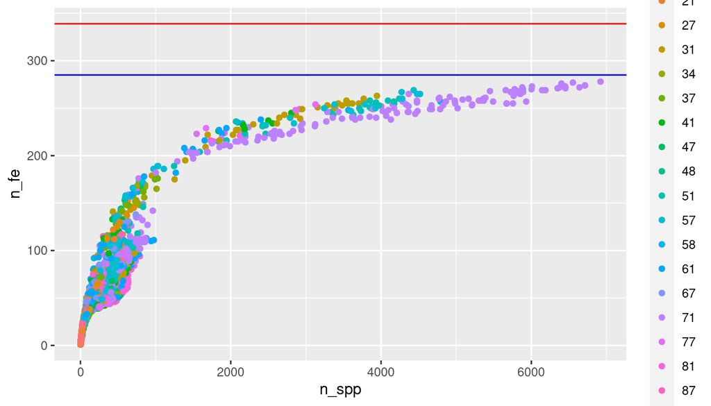

```r
nspp_r <- rast(here('_output/func_entities/n_spp.tif'))
n_fe_r <- rast(here('_output/func_entities/n_fe.tif'))
fao_rgns_r <- rast(here('_spatial/fao_mol.tif')) %>% setNames('fao')

regr_df <- data.frame(c(nspp_r, n_fe_r, fao_rgns_r))

set.seed(42)
regr_sample_df <- regr_df %>%
  filter(!is.na(fao)) %>%
  sample_n(10000) %>%
  mutate(fao = factor(fao))

tot_fes_repr <- 339
max_fes_repr <- minmax(n_fe_r)[2]

ggplot(regr_sample_df, aes(x = n_spp, y = n_fe, color = fao)) +
  geom_point() +
  geom_hline(yintercept = tot_fes_repr, color = 'red') +
  geom_hline(yintercept = max_fes_repr, color = 'blue')
```

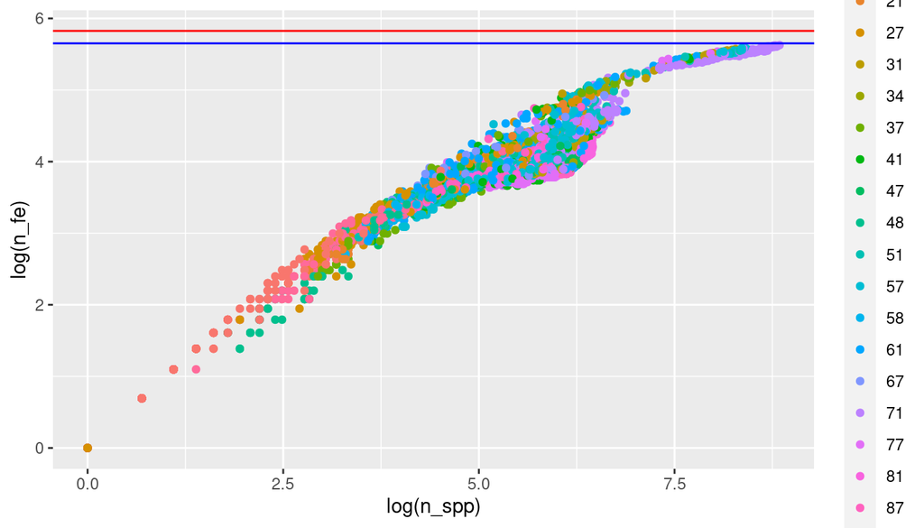

```r
ggplot(regr_sample_df, aes(x = log(n_spp), y = log(n_fe), color = fao)) +
  geom_point() +
  geom_hline(yintercept = log(tot_fes_repr), color = 'red') +
  geom_hline(yintercept = log(max_fes_repr), color = 'blue')
```

```r
nls_mdl <- nls(n_fe ~ a * n_spp^b, data = regr_sample_df, start = list(a = 1, b = .5))

summary(nls_mdl)
```

```
##
## Formula: n_fe ~ a * n_spp^b
##
## Parameters:
##   Estimate Std. Error t value Pr(>|t|)
## a 1.526965   0.020438   74.71   <2e-16 ***
## b 0.610166   0.001978  308.45   <2e-16 ***
## ---
## Signif. codes:  0 '***' 0.001 '**' 0.01 '*' 0.05 '.' 0.1 ' ' 1
##
## Residual standard error: 14.07 on 9996 degrees of freedom
##
## Number of iterations to convergence: 4
## Achieved convergence tolerance: 5.93e-06
##   (2 observations deleted due to missingness)
```

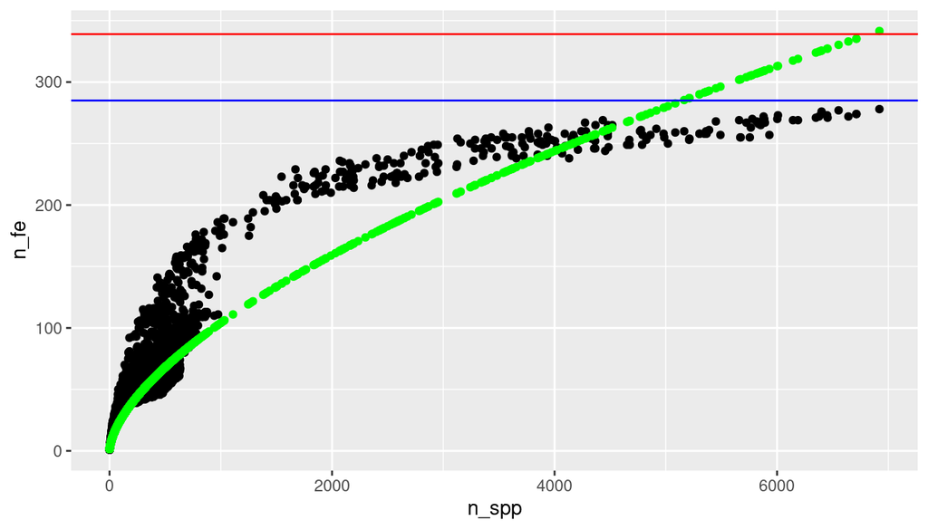

```r
ggplot(regr_sample_df, aes(x = n_spp, y = n_fe)) +
  geom_point() +
  geom_point(aes(y = 1.497 * n_spp^.6141), color = 'green') +
  geom_hline(yintercept = tot_fes_repr, color = 'red') +
  geom_hline(yintercept = max_fes_repr, color = 'blue')
```

But that doesn’t look like a great fit! Try something like this

$$f(x) = 1 - \frac{1}{x+1}$$

```r
nls_mdl <- nls(n_fe ~ a * n_spp / (n_spp + b),
               data = regr_sample_df %>% sample_n(100),
               start = list(a = 200, b = 1))

summary(nls_mdl)
```

```
##
## Formula: n_fe ~ a * n_spp/(n_spp + b)
##
## Parameters:
##   Estimate Std. Error t value Pr(>|t|)
## a   370.93      21.82   17.00   <2e-16 ***
## b  2204.17     187.93   11.73   <2e-16 ***
## ---
## Signif. codes:  0 '***' 0.001 '**' 0.01 '*' 0.05 '.' 0.1 ' ' 1
##
## Residual standard error: 13.42 on 98 degrees of freedom
##
## Number of iterations to convergence: 10
## Achieved convergence tolerance: 2.205e-06
```

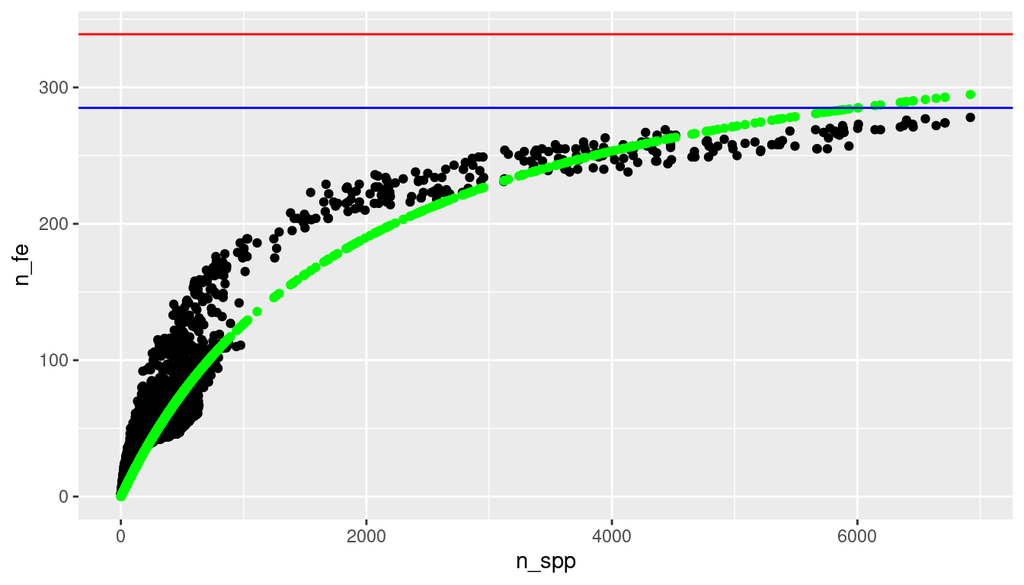

```r
ggplot(regr_sample_df, aes(x = n_spp, y = n_fe)) +
  geom_point() +
  geom_point(aes(y = 380 * (n_spp / (n_spp + 2000))), color = 'green') +
  geom_hline(yintercept = tot_fes_repr, color = 'red') +
  geom_hline(yintercept = max_fes_repr, color = 'blue')
```

or

$$N_{FE} = a \arctan (b \cdot
N_{spp})$$

```r
nls_mdl <- nls(n_fe ~ a * atan(b * n_spp),
               data = regr_sample_df,
               start = list(a = 200, b = 1))

summary(nls_mdl)
```

```
##
## Formula: n_fe ~ a * atan(b * n_spp)
##
## Parameters:
##    Estimate Std. Error t value Pr(>|t|)
## a 2.061e+02  1.268e+00   162.6   <2e-16 ***
## b 7.191e-04  5.663e-06   127.0   <2e-16 ***
## ---
## Signif. codes:  0 '***' 0.001 '**' 0.01 '*' 0.05 '.' 0.1 ' ' 1
##
## Residual standard error: 15.18 on 9996 degrees of freedom
##
## Number of iterations to convergence: 12
## Achieved convergence tolerance: 2.888e-06
##   (2 observations deleted due to missingness)
```

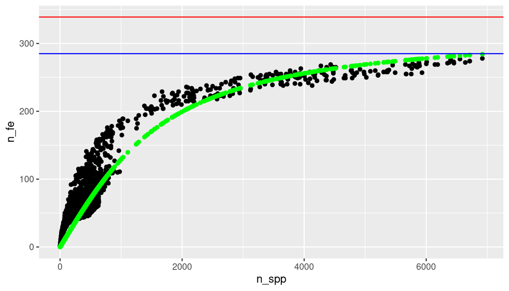

```r
ggplot(regr_sample_df, aes(x = n_spp, y = n_fe)) +
  geom_point() +
  geom_point(aes(y = 207 * atan(7.2e-4 * n_spp)), color = 'green') +
  geom_hline(yintercept = tot_fes_repr, color = 'red') +
  geom_hline(yintercept = max_fes_repr, color = 'blue')
```

## 2.2 Spp richness vs. functional vulnerability

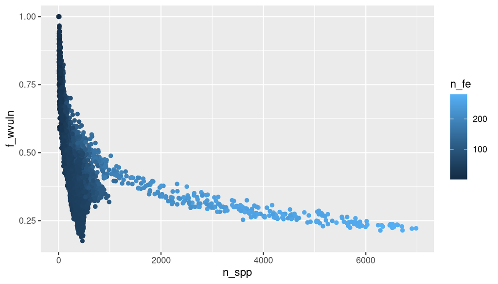

```r
nspp_r  <- rast(here('_output/func_entities/n_spp.tif'))
fvuln_r <- rast(here('_output/func_entities/f_wvuln.tif'))

nspp_v_vuln_df <- data.frame(c(nspp_r, n_fe_r, fvuln_r))

regr_sample_df <- nspp_v_vuln_df %>%
  sample_n(10000)

ggplot(regr_sample_df, aes(x = n_spp, y = f_wvuln, color = n_fe)) +
  geom_point()
```

## 2.3 Spp richness vs. CHI

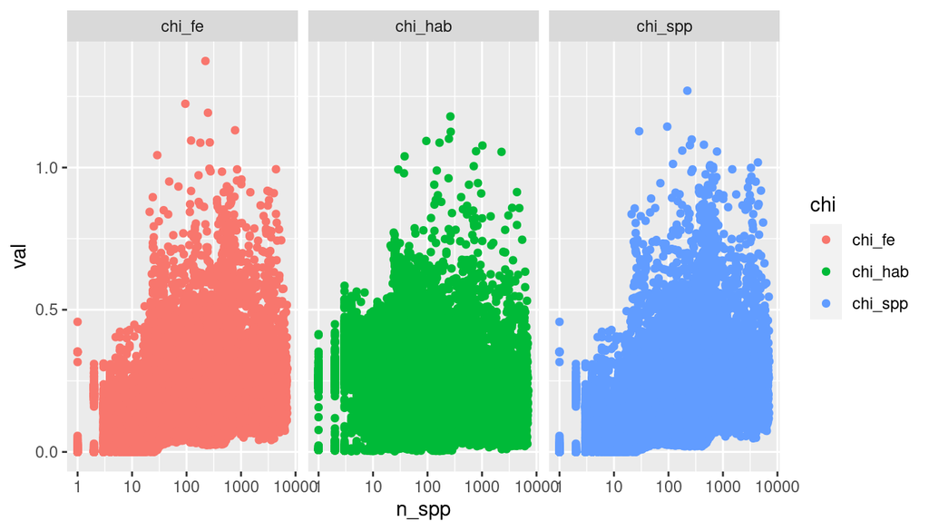

```r
nspp_r  <- rast(here('_output/func_entities/n_spp.tif'))
chi_spp_r <- rast(here('_output/cumulative_impact_maps/chi_species.tif'))
chi_fe_r  <- rast(here('_output/cumulative_impact_maps/chi_funct_entity.tif'))
chi_hab_r <- rast(here('_output/cumulative_impact_maps/chi_habitat.tif')) / 5

nspp_v_chi_df <- data.frame(c(nspp_r, chi_spp_r, chi_fe_r, chi_hab_r))
regr_sample_df <- nspp_v_chi_df %>%
  sample_n(100000)

plot_df <- regr_sample_df %>%
  pivot_longer(names_to = 'chi', values_to = 'val', -n_spp)


ggplot(plot_df, aes(x = n_spp, y = val)) +
  geom_point(aes(color = chi)) +
  scale_x_log10() +
  facet_wrap(~chi)
```

```r
spp_mdl <- lm(chi_spp ~ n_spp, data = regr_sample_df)
fe_mdl  <- lm(chi_fe  ~ n_spp, data = regr_sample_df)
hab_mdl <- lm(chi_hab ~ n_spp, data = regr_sample_df)
summary(spp_mdl)
```

```
##
## Call:
## lm(formula = chi_spp ~ n_spp, data = regr_sample_df)
##
## Residuals:
##      Min       1Q   Median       3Q      Max
## -0.27211 -0.04831 -0.02386  0.01965  1.15962
##
## Coefficients:
##              Estimate Std. Error t value Pr(>|t|)
## (Intercept) 1.019e-01  3.305e-04  308.49   <2e-16 ***
## n_spp       3.832e-05  4.848e-07   79.05   <2e-16 ***
## ---
## Signif. codes:  0 '***' 0.001 '**' 0.01 '*' 0.05 '.' 0.1 ' ' 1
##
## Residual standard error: 0.08626 on 99917 degrees of freedom
##   (81 observations deleted due to missingness)
## Multiple R-squared:  0.05886,    Adjusted R-squared:  0.05885
## F-statistic:  6248 on 1 and 99917 DF,  p-value: < 2.2e-16
```

```r
summary(fe_mdl)
```

```
##
## Call:
## lm(formula = chi_fe ~ n_spp, data = regr_sample_df)
##
## Residuals:
##      Min       1Q   Median       3Q      Max
## -0.23921 -0.04901 -0.01729  0.02453  1.25434
##
## Coefficients:
##              Estimate Std. Error t value Pr(>|t|)
## (Intercept) 1.132e-01  3.071e-04  368.59   <2e-16 ***
## n_spp       3.150e-05  4.506e-07   69.91   <2e-16 ***
## ---
## Signif. codes:  0 '***' 0.001 '**' 0.01 '*' 0.05 '.' 0.1 ' ' 1
##
## Residual standard error: 0.08016 on 99917 degrees of freedom
##   (81 observations deleted due to missingness)
## Multiple R-squared:  0.04663,    Adjusted R-squared:  0.04662
## F-statistic:  4887 on 1 and 99917 DF,  p-value: < 2.2e-16
```

```r
summary(hab_mdl)
```

```
##
## Call:
## lm(formula = chi_hab ~ n_spp, data = regr_sample_df)
##
## Residuals:
##      Min       1Q   Median       3Q      Max
## -0.23127 -0.05579 -0.01233  0.04309  0.95080
##
## Coefficients:
##               Estimate Std. Error t value Pr(>|t|)
## (Intercept)  2.338e-01  3.178e-04  735.85   <2e-16 ***
## n_spp       -1.921e-05  4.681e-07  -41.05   <2e-16 ***
## ---
## Signif. codes:  0 '***' 0.001 '**' 0.01 '*' 0.05 '.' 0.1 ' ' 1
##
## Residual standard error: 0.08277 on 99687 degrees of freedom
##   (311 observations deleted due to missingness)
## Multiple R-squared:  0.01662,    Adjusted R-squared:  0.01661
## F-statistic:  1685 on 1 and 99687 DF,  p-value: < 2.2e-16
```

## 2.4 FV vs. CHI

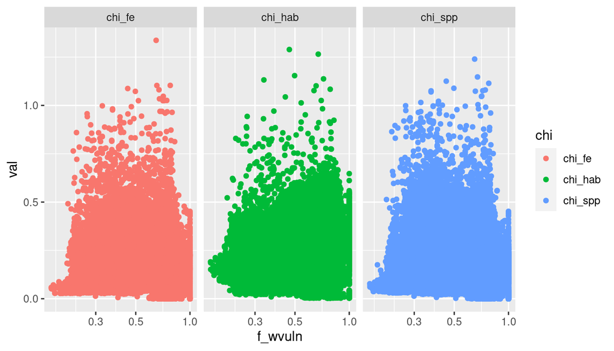

```r
fv_r  <- rast(here('_output/func_entities/f_wvuln.tif'))
chi_spp_r <- rast(here('_output/cumulative_impact_maps/chi_species.tif'))
chi_fe_r  <- rast(here('_output/cumulative_impact_maps/chi_funct_entity.tif'))
chi_hab_r <- rast(here('_output/cumulative_impact_maps/chi_habitat.tif')) / 5

fv_v_chi_df <- data.frame(c(fv_r, chi_spp_r, chi_fe_r, chi_hab_r))
regr_sample_df <- fv_v_chi_df %>%
  sample_n(100000)

plot_df <- regr_sample_df %>%
  pivot_longer(names_to = 'chi', values_to = 'val', -f_wvuln)


ggplot(plot_df, aes(x = f_wvuln, y = val)) +
  geom_point(aes(color = chi)) +
  scale_x_log10() +
  facet_wrap(~chi)
```

```r
spp_mdl <- lm(chi_spp ~ f_wvuln, data = regr_sample_df)
fe_mdl  <- lm(chi_fe  ~ f_wvuln, data = regr_sample_df)
hab_mdl <- lm(chi_hab ~ f_wvuln, data = regr_sample_df)
summary(spp_mdl)
```

```
##
## Call:
## lm(formula = chi_spp ~ f_wvuln, data = regr_sample_df)
##
## Residuals:
##      Min       1Q   Median       3Q      Max
## -0.14067 -0.05085 -0.02561  0.02165  1.11382
##
## Coefficients:
##              Estimate Std. Error t value Pr(>|t|)
## (Intercept) 0.0984455  0.0007832  125.69   <2e-16 ***
## f_wvuln     0.0422237  0.0016805   25.12   <2e-16 ***
## ---
## Signif. codes:  0 '***' 0.001 '**' 0.01 '*' 0.05 '.' 0.1 ' ' 1
##
## Residual standard error: 0.08882 on 99925 degrees of freedom
##   (73 observations deleted due to missingness)
## Multiple R-squared:  0.006278,   Adjusted R-squared:  0.006268
## F-statistic: 631.3 on 1 and 99925 DF,  p-value: < 2.2e-16
```

```r
summary(fe_mdl)
```

```
##
## Call:
## lm(formula = chi_fe ~ f_wvuln, data = regr_sample_df)
##
## Residuals:
##      Min       1Q   Median       3Q      Max
## -0.16508 -0.04915 -0.01822  0.02568  1.19641
##
## Coefficients:
##              Estimate Std. Error t value Pr(>|t|)
## (Intercept) 0.0946403  0.0007144  132.47   <2e-16 ***
## f_wvuln     0.0704407  0.0015329   45.95   <2e-16 ***
## ---
## Signif. codes:  0 '***' 0.001 '**' 0.01 '*' 0.05 '.' 0.1 ' ' 1
##
## Residual standard error: 0.08102 on 99925 degrees of freedom
##   (73 observations deleted due to missingness)
## Multiple R-squared:  0.02069,    Adjusted R-squared:  0.02068
## F-statistic:  2112 on 1 and 99925 DF,  p-value: < 2.2e-16
```

```r
summary(hab_mdl)
```

```
##
## Call:
## lm(formula = chi_hab ~ f_wvuln, data = regr_sample_df)
##
## Residuals:
##      Min       1Q   Median       3Q      Max
## -0.29275 -0.05182 -0.01216  0.04099  1.05893
##
## Coefficients:
##              Estimate Std. Error t value Pr(>|t|)
## (Intercept) 0.1730043  0.0007188  240.69   <2e-16 ***
## f_wvuln     0.1229793  0.0015439   79.65   <2e-16 ***
## ---
## Signif. codes:  0 '***' 0.001 '**' 0.01 '*' 0.05 '.' 0.1 ' ' 1
##
## Residual standard error: 0.08135 on 99717 degrees of freedom
##   (281 observations deleted due to missingness)
## Multiple R-squared:  0.05982,    Adjusted R-squared:  0.05981
## F-statistic:  6345 on 1 and 99717 DF,  p-value: < 2.2e-16
```

## 2.5 FE vs. spp vs. hab CHI

```r
chi_spp_r <- rast(here('_output/cumulative_impact_maps/chi_species.tif'))
chi_fe_r  <- rast(here('_output/cumulative_impact_maps/chi_funct_entity.tif'))
chi_hab_r <- rast(here('_output/cumulative_impact_maps/chi_habitat.tif')) / 5

chi_v_chi_df <- data.frame(c(chi_spp_r, chi_fe_r, chi_hab_r))
regr_sample_df <- chi_v_chi_df # %>%
  # sample_n(100000)

spp_fe_mdl  <- lm(chi_spp ~ chi_fe, data = regr_sample_df)
fe_hab_mdl  <- lm(chi_fe  ~ chi_hab, data = regr_sample_df)
spp_hab_mdl <- lm(chi_spp ~ chi_hab, data = regr_sample_df)
summary(spp_fe_mdl)
```

```
##
## Call:
## lm(formula = chi_spp ~ chi_fe, data = regr_sample_df)
##
## Residuals:
##      Min       1Q   Median       3Q      Max
## -0.28477 -0.01731  0.00121  0.01576  0.35461
##
## Coefficients:
##               Estimate Std. Error t value Pr(>|t|)
## (Intercept) -1.147e-02  2.801e-05  -409.6   <2e-16 ***
## chi_fe       1.024e+00  1.874e-04  5463.3   <2e-16 ***
## ---
## Signif. codes:  0 '***' 0.001 '**' 0.01 '*' 0.05 '.' 0.1 ' ' 1
##
## Residual standard error: 0.02936 on 3679990 degrees of freedom
##   (3341 observations deleted due to missingness)
## Multiple R-squared:  0.8902, Adjusted R-squared:  0.8902
## F-statistic: 2.985e+07 on 1 and 3679990 DF,  p-value: < 2.2e-16
```

```r
summary(fe_hab_mdl)
```

```
##
## Call:
## lm(formula = chi_fe ~ chi_hab, data = regr_sample_df)
##
## Residuals:
##      Min       1Q   Median       3Q      Max
## -0.26238 -0.04084 -0.01884  0.01690  1.07510
##
## Coefficients:
##              Estimate Std. Error t value Pr(>|t|)
## (Intercept) 0.0174809  0.0001070   163.4   <2e-16 ***
## chi_hab     0.4753699  0.0004434  1072.0   <2e-16 ***
## ---
## Signif. codes:  0 '***' 0.001 '**' 0.01 '*' 0.05 '.' 0.1 ' ' 1
##
## Residual standard error: 0.07102 on 3671786 degrees of freedom
##   (11545 observations deleted due to missingness)
## Multiple R-squared:  0.2384, Adjusted R-squared:  0.2384
## F-statistic: 1.149e+06 on 1 and 3671786 DF,  p-value: < 2.2e-16
```

```r
summary(spp_hab_mdl)
```

```
##
## Call:
## lm(formula = chi_spp ~ chi_hab, data = regr_sample_df)
##
## Residuals:
##      Min       1Q   Median       3Q      Max
## -0.24056 -0.03981 -0.02565  0.00730  1.02500
##
## Coefficients:
##              Estimate Std. Error t value Pr(>|t|)
## (Intercept) 0.0167344  0.0001209   138.4   <2e-16 ***
## chi_hab     0.4409478  0.0005012   879.7   <2e-16 ***
## ---
## Signif. codes:  0 '***' 0.001 '**' 0.01 '*' 0.05 '.' 0.1 ' ' 1
##
## Residual standard error: 0.08028 on 3671786 degrees of freedom
##   (11545 observations deleted due to missingness)
## Multiple R-squared:  0.1741, Adjusted R-squared:  0.1741
## F-statistic: 7.739e+05 on 1 and 3671786 DF,  p-value: < 2.2e-16
```